# Testes de Homocedasticidade para k populações

Estatística Computacional II

Konstanz Tonegawa Winter, Nathan Machado

Novembro, 2017

## Aspectos Motivacionais

Homocedasticidade é o termo para designar variância constante em observações distintas. Em casos de heterocedasticidade podemos concluir que a inferência estatística não será válida e não podemos afirmar que os EQM são os melhores estimadores de mínima variância.

Para testar a homocedasticidade, testamos a hipótese de igualdade de variância:

$$H_0 : \sigma_1^2 = \sigma_2^2 = ... = \sigma_n^2$$
$$H_1 : pelo\ menos\ um\ dos\ \sigma_i^{2's} diferente,~~i=1,...,n$$
Dado um modelo de regressão linear:
$$y_i=\beta_0+\beta_1x_{1,i}+...+\beta_px_{p,i}+\varepsilon_i,~~i=1,...,n$$

Utilizamos alguns testes em k amostras sob $H_0$ (variâncias iguais):

Bartlett: É utilizado quando a hipótese de normalidade não for violada, pois é sensível devido às saídas da normalidade e pode retornar falsos positivos. A estatística de teste é dada por:
$$B_0=q/c$$
em que
$$q=(N-k)*ln s^2_p-\sum_{i=1}^{k}[(n_i-1)*ln s^2_i]$$
$$c=1+\frac{1}{3(k-1)}\left(\sum_{i=1}^{k}\frac{1}{n_i-1}-\frac{1}{N-k}\right)$$
$$s^2_p=\frac{1}{N-k}\sum_{i=1}^{k}(n_i-1) s^2_i$$
$$s^2_i=\sum_{j=1}^{n_i}\frac{(y_{ij}-\bar{y}_i.)^2}{n_i-1}$$
$$P-valor = P[\chi^2_{k-1}>B_0|H_0]$$
A estatística do teste é aproximadamente qui-quadrado.

Levene: É um teste não paramétrico utilizado pelo poder de robustez, ou seja, sua capacidade de não detectar falsamente variações desiguais quando os dados não são normalmente distribuídos e as variâncias são constantes. Neste teste o procedimento consiste em transformar dos dados originais e aplicar aos dados transformados o teste da ANOVA. Levene (1960) propôs a seguinte transformação: (Portal Action)

$$z_{ij}=|x_{ij}-\bar{x}_i|,~~i=1,...k~~e~~j=1,...,n_i$$
onde $z_{ij}:representa~~os~~dados~~após~~transformação$ $x_{ij}:representa~~os~~dados~~originais$ $\bar{x}_i:representa~~a~~média~~do~~nível~~i,~~para~~os~~dados~~originais$

e com isso a estatística do teste:

$$F^*=\frac{\frac{\sum_{i=1}^{k}\frac{n_i(\bar{z_i}-\bar{z}..)^2}{k-1}}{\sum_{i=1}^{k}\sum_{j=1}^{n_i}(z_{ij}-\bar{z_i})^2}}{\sum_{i=1}^{k}(n_i-1)}$$

Fligner: É este não paramétrico e também é robusto para saídas de normalidade. Ele difere do teste Levene por utilizar a centralização mediana em cada uma das amostras.

Este teste é feito como Levene, substituindo a média do nível pela mediana.

$$z_{ij}=|x_{ij}-\hat{x}_i|,~~i=1,...k~~e~~j=1,...,n_i$$
$\hat{x}_i:representa~~a~~média~~do~~nível~~i,~~para~~os~~dados~~originais$

## Descrição do estudo de simulação

No presente trabalho desenvolvemos uma simulação para testes de homocedasticidade para k populações, considerando os fatores:

[output not shown]

Com a finalidade de comparar o poder dos três testes e situações distintas.

## Implementação em código R com comentários

```r
library(car)
require(reshape2)
#set.seed(1234)

# Criar a função que irá realizar as simulações

simulaPop <- function(n, pop, phi, dist, teste){

  # Simulação de 3000 repetições
  sum({replicate(3000,{popCont <- 1
  Dados <- list()

  # Laço para gerar k populações com n amostras
  while(popCont <= pop){
    Dados[popCont] <- data.frame(matrix(switch(dist,
                               Norm = {rnorm(n, sd = sqrt(((phi*popCont)+1)))},
                               Unif = {runif(n, min = -(sqrt(12 * ((phi*popCont)+1)) / 2),                                               max = sqrt(12 * ((phi*popCont)+1)) / 2)},
                               Pois = {rpois(n, (phi*popCont)+1)})))
    popCont <- popCont + 1}

  df <- data.frame(matrix(unlist(Dados),ncol=1))

  indicePop <- list()

# Cria uma lista com os nomes das populações
for (i in 1:pop){
  nms <- rep(paste("Pop",i),n)
  indicePop <- append(indicePop,nms)
}

indicePop <- unlist(indicePop)
df[2] <- indicePop
names(df) <- c("Observações", "População")

# Calcula o p-valor com base no teste especificado
Pvalor <- switch(teste,
                   Bartlet = {bartlett.test(df$Observações ~ df$População)$p.value},
                   Fligner = {fligner.test(df$Observações, factor(df$População))$p.value},
                   Levene = {leveneTest(df$Observações, factor(df$População))$'Pr(>F)'[1]})
  Pvalor})}<0.05)/3000
}
set.seed(1234)

# Tabela com todas as combinações dos parâmetros da função
Parametros <- expand.grid(n = c(10,40,80),
                          pop = c(2,5,8),
                          phi = seq(from = 0, to = 1, by = 0.1),
                          dist = c("Norm","Unif","Pois"),
                          teste = c("Bartlet","Fligner","Levene"))

# Executa a função para cada combinação de parâmetros
x <- mapply(FUN = simulaPop,
            n = Parametros$n,
            pop = Parametros$pop,
            phi = Parametros$phi,
            dist = as.character(Parametros$dist),
            test = as.character(Parametros$teste))

d <- data.frame(Parametros,x)

library(ggplot2)
library(latex2exp)

dists <- c("Norm","Pois","Unif")
```

## Principais resultados em formato de gráficos ou tabelas com a discussão

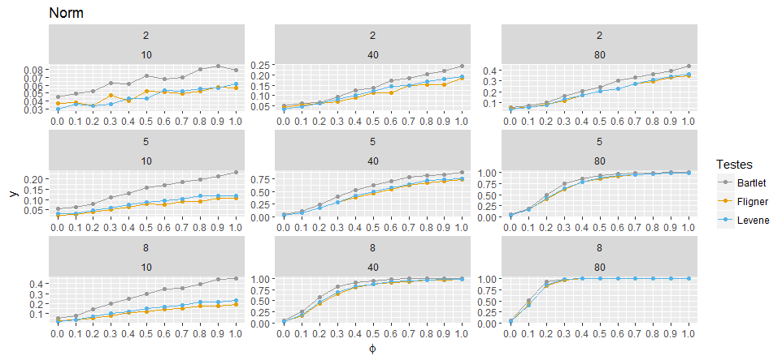

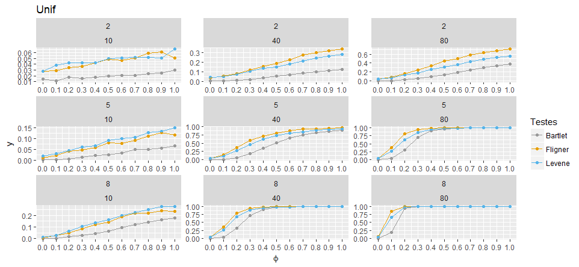

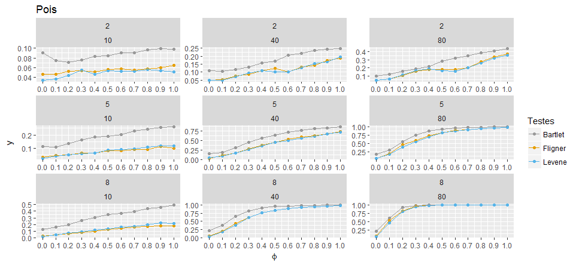

```r
# Gera gráficos comparativos dos testes para diferentes amostras, populações, etc
p <- lapply(dists, function(x){
  ggplot(d[d$dist == x,], aes(x = phi, y = x, colour = teste)) +
    geom_point() + geom_line(stat = "identity") +
    facet_wrap(~ pop + n,scales = "free") +
    scale_x_continuous(breaks= seq(0, 1, by = 0.1)) +
    labs(x = TeX("$\\phi$"), y = "y") +
    ggtitle(x) +
    scale_color_manual(values=c("#999999", "#E69F00", "#56B4E9"),
                       name="Testes",
                       breaks=c("Bartlet", "Fligner", "Levene"),
                       labels=c("Bartlet", "Fligner", "Levene"))
})

# p é uma lista que contêm os plots na sequencia do objeto dists

p[[1]] # Norm

p[[2]] # Pois

p[[3]] # Unif
```

## Recomendações e conclusões do trabalho

É recomendado que quando os dados forem normais utilize-se do teste Bartlett devido sua sensibilidade a hipótese de normalidade dos dados, se rejeitarmos a hipótese de normalidade o recomentado é utilizar o teste Levene, sendo um teste mais robusto. E pelas simulações observamos que quando os dados não atendem a normalidade o teste de fligner é melhor que o levene.

Segundo o TCL (teorema central do limite), observamos nos testes que com o aumento da população conseguimos aproximar qualquer distribuição para a normal, com isso o poder de teste entre os testes se aproxima.

Observamos no gráfico de poisson que mesmo o teste bartlett rejeitando mais, ele é um teste liberal, pois quando há um aumento de amostra e população a taxa de rejeição é de aproximadamente 25% e o ideal seria 5%.

Para planejamentos, verificamos a análise de variância porque ele decompõe a total em variância dentro dos grupos (o “erro”) e a variação entre o grupo significa. Por isso, testa se os meios do grupo são iguais, comparando a variância entre eles e o esperado com base apenas na variância dentro do grupo: a variação entre os significados do grupo é “maior do que o esperado por acaso”, ou seja, puramente da variabilidade da amostragem. Isso é totalmente diferente do teste de Levene ou outros, que testam se as variações dos grupos são iguais. Heuristicamente, os testes de Levene e Brown-Forsythe (eu não tenho certeza sobre Fligner, desculpe, Mike) são como ANOVA nos quadrados ou valores absolutos dos resíduos dentro do grupo, então eles testaram, por sua vez, se a magnitude média dos resíduos - - assim a variabilidade dentro do grupo - difere entre os grupos.

## Referências

http://www.portalaction.com.br/anova/161-teste-de-igualdade-das-variancias

https://mixedpsychophysics.wordpress.com/r-code-a-test/changing-the-parameters-in-a-plot/